# Drawing insights

Now that we have gathhered assessed and cleaned our data, we now proceed to carry out further analysis so as to come up with meaningful insights. From the summary statistics we find that:

The value for the rating_denominator is a constant value of 10.

The average rating_numerator is 11.220812 with maximum and minimum being 27 and 3 respectively.

The most favourated dog is in the puppo stage

The most retweeted dog is in the doggo stage

Algorithm#1 has the highest precision of prediction with and average confident interval of 61.9% and a maximum of 99.9984 %.

Now that we have gathhered assessed and cleaned our data, we now proceed to carry out further analysis so as to come up with meaningful insights. Here we report on four insights based on:

1. Summary statistics
2. Skewness
3. Correlation
4. Efficiency of algorithm

### 1. Summary statistics

The value for the rating_denominator is a constant value of 10.

The average rating_numerator is 11.220812 with maximum and minimum being 27 and 3 respectively.

The most favourated dog is in the puppo stage

The most retweeted dog is in the doggo stage

### 2. Skewness

A histogram plot depicted the following

The confidence interval of algorithm#1 is skewed to the left while for algorithm#2 and algorithm#3 is skewed to the right

FavouriteCount and Retweet count are both skewed to the right.

Histogram plots for RetweetCount, Favourite count, Rating denominator, Rating numerator and confidence intervals for algorithm 1, 2 and 3.

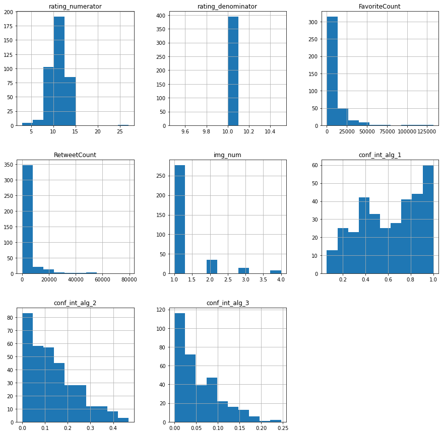

### 3. Correlation

A scatter plot depicted the following:

There is a positive correlation between 'favouriteCount' and the 'retweetCount'

The confidence interval of algorithm#1 is negatively correlated with algorithm#2 and algorithm#3

Rating denominator is constant and does not change with changes in confidence intervals.

A scatter plot matrix showing the relationship between variables

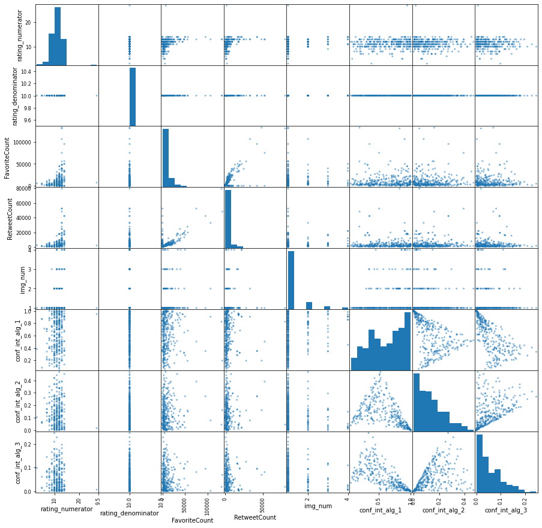

**In conclusion** : Algorithm#1 is the most efficient and appropriate for image prediction.